# ELISA Method Validation and Method Comparison

Lenny Lin

# Introduction

A LC-MS/MS method is a reference method of determining a contaminant in food. An `ELISA`method was developed for screening the contaminant. The method validation of ELISA was composed of two parts, the first part was to verify whether the ELISA method is fit for the screening purpose, the second part was to verify whether the ELISA method is comparable with the LC-MS/MS method.

The analysis of validation data revealed that the ELISA method is accurate and precious and it could be used for screening purpose.

This work demonstrates the author’s skills in statistical analysis in R and reporting with R Markdown. I only provided some of method validation results in this work.

# Experimental Schemes

**Part I: Method validation of ELISA**  
The precision and accuracy of the ELISA were evaluated using replicate fortified samples (n = 5 replicates per day over three days).

1) A blank sample was grounded followed by being fortified at 1, 5, and 10 ppm. Five replicate test portions at each fortified level were tested every day for three days.

2) A blank sample, control standard at 0.75ppb, and QC sample were analyzed in every run. All extract from each test portion, standard, and QC sample were analyzed in duplicate.

3) Duplicates within 20% were considered valid and were calculated to obtain results; otherwise, extraction and preparation were repeated.

4) When fortified samples initially produced results outside of the range of the calibration curve, additional dilutions were performed on the extract to allow for analysis on the curve. Final dilutions of 1:200, 1:400, and 1:600 (v/v) were used when appropriate.

**Part II: Comparison of ELISA with LC-MS/MS**  
30 samples were tested on ELISA plate as well as with LC-MS/MS.

# Method validation of ELISA

## Within-day Precision and Accuracy

Precision is defined as the closeness of agreement between independent test results obtained under stipulated conditions. [1]

Precision was evaluated by assessing the mean and the associated standard deviation at different fortification levels, as well as the within-day `%CV` [2] and between-day %CVs. In this method validation study, I followed these criteria: The within-day %CVs should be less than 10. The between-day %CVs of less than 15 are generally acceptable [3].

Accuracy was evaluated by assessing the percent recovery of fortified samples at different fortification levels.

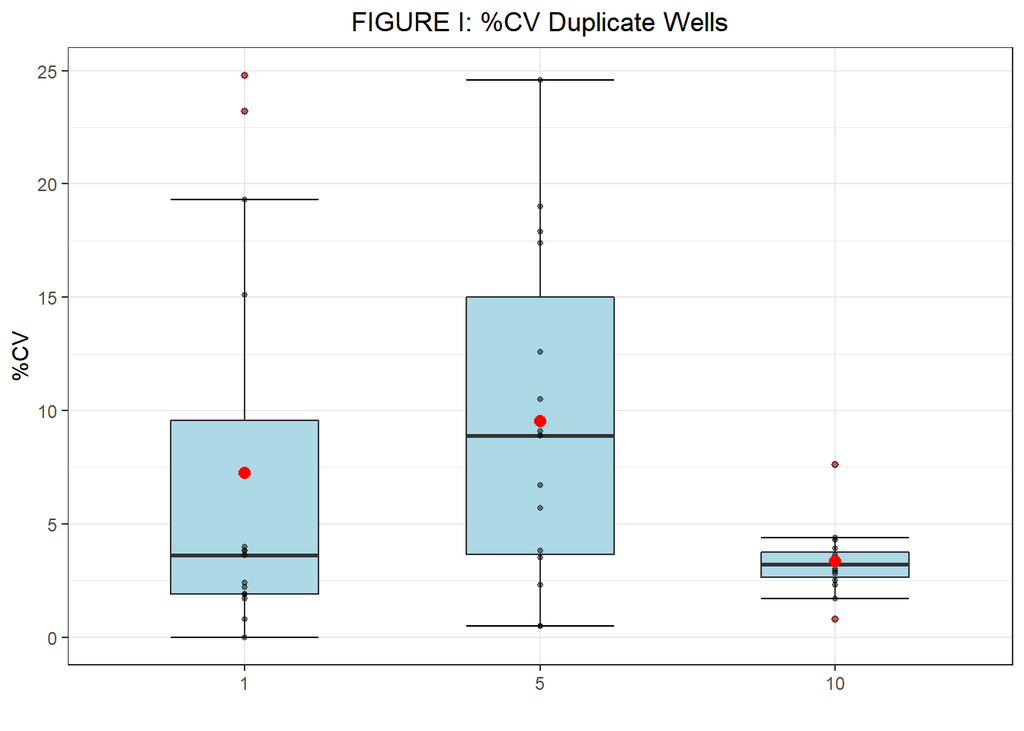

The %CV of 4 replicates were over 15% out of 15 replicates at fortification level 1ppm. The %CV of other 11 replicates were less than 5%. Two replicates had %CV over 20% and they will be removed prior to further calculation.  
The %CVs were spread broadly from 0.5 to 25% at fortification level 5ppm. There is one replicate having %CV over 20% and they will be removed prior to further calculation.  
The %CVs of all replicates at fortification level 10ppm were less than 10%.

| TABLE II: Within-day Precision and Accuracy at Three Fortification Levels Stats | TABLE II: Within-day Precision and Accuracy at Three Fortification Levels Day 1 | TABLE II: Within-day Precision and Accuracy at Three Fortification Levels Day 2 | TABLE II: Within-day Precision and Accuracy at Three Fortification Levels Day 3 |
| --- | --- | --- | --- |
| **Sample fortified at 1ppm** |  |  |  |
| mean ± SD | 0.98 ± 0.15 | 0.94 ± 0.10 | 1.04 ± 0.16 |
| mean % recovery | 98 | 94 | 104 |
| %CV | 14.79 | 10.38 | 15.07 |
| **Sample fortified at 5ppm** |  |  |  |
| mean ± SD | 4.44 ± 0.41 | 6.00 ± 0.41 | 5.24 ± 0.28 |
| mean % recovery | 89 | 120 | 105 |
| %CV | 9.21 | 6.86 | 5.4 |
| **Sample fortified at 10ppm** |  |  |  |
| mean ± SD | 10.68 ± 0.84 | 10.02 ± 1.00 | 10.51 ± 0.65 |
| mean % recovery | 107 | 100 | 105 |
| %CV | 7.88 | 9.95 | 6.18 |

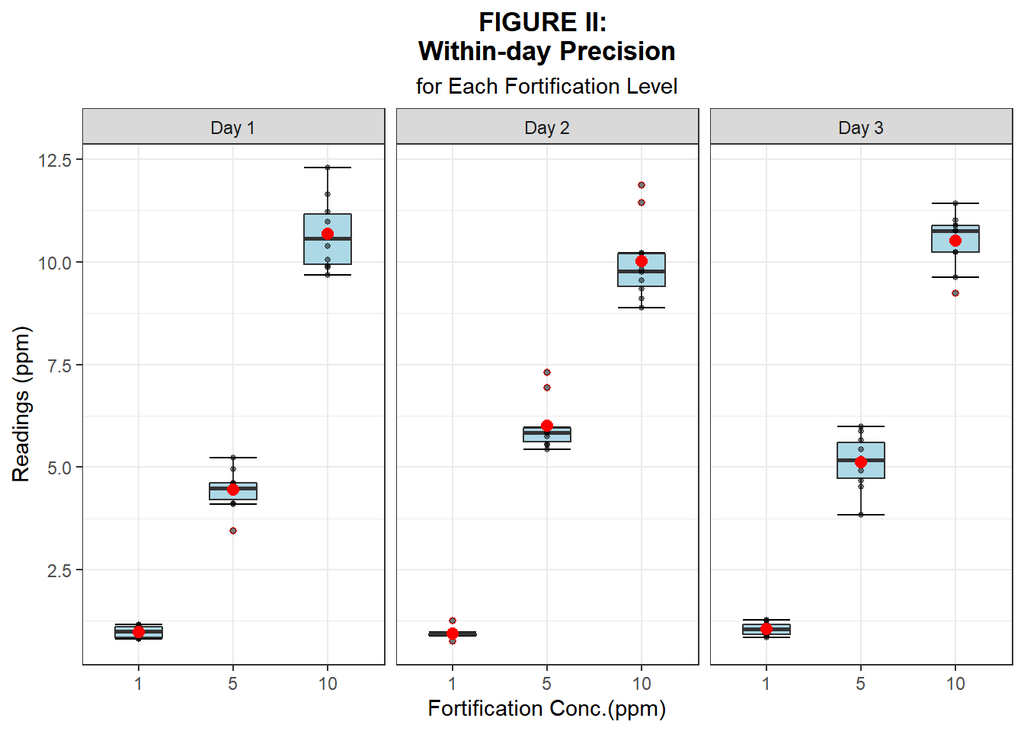

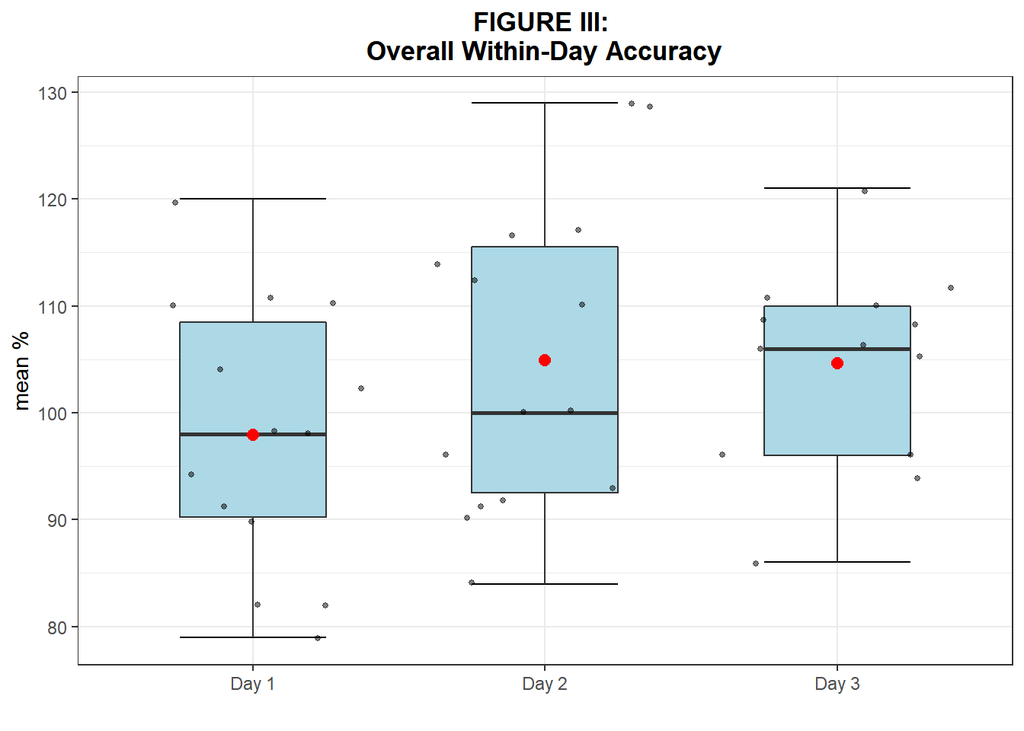

Table II summarized the within-day precision and accuracy. Figure II and III visualized the precision and accuracy.

The ELISA method had good accuracy, with the `mean % recovery` ranging from 89 to 120%, at each fortification level (1, 5, 10 ppm) in each day (table II).

With the %CVs ranging from 5.4 to 9.95%, the ELISA method had good precision at 5 and 10ppm fortification levels in each day, but the %CVs were between 10.38 and 15.07% at 1 ppm fortification levels.

## Precision: Intermediate Precision (Rw) / Between Day Repeatability

| TABLE III: Overall Between-day Precision Stat | TABLE III: Overall Between-day Precision 1 ppm | TABLE III: Overall Between-day Precision 5 ppm | TABLE III: Overall Between-day Precision 10 ppm |
| --- | --- | --- | --- |
| %CV | 4.65 | 8.46 | 3.33 |

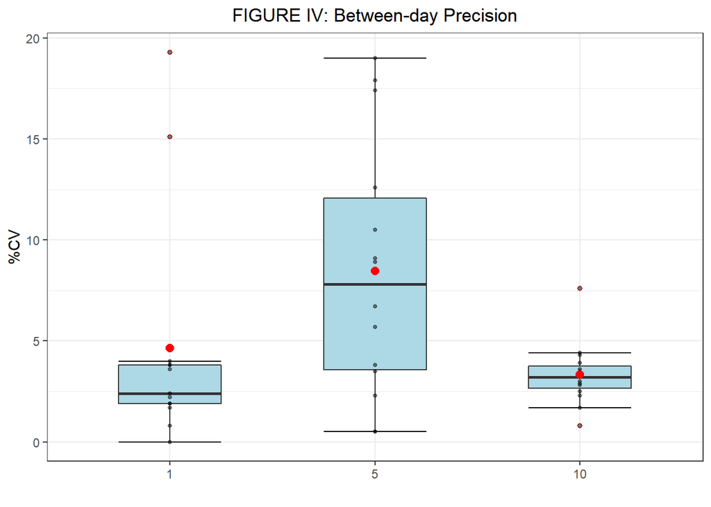

The overall between-day precision is good with %CV ranging from 3.33 to 8.46%.

# Comparison of ELISA method with the reference LC-MS/MS method

The performance of the ELISA was further evaluated by comparison of ELISA-generated data to those from the LC-MS/MS method. The raw data less than the LOQs were altered by removing the `<` symbol for plotting purpose.

| TABLE IV: Comparison Data (ppm) ELISA | TABLE IV: Comparison Data (ppm) LCMSMS |
| --- | --- |
| 0.32 | <0.05 |
| 0.54 | 0.302 |
| 4.41 | 3.64 |
| 1.81 | 1.678 |
| 2.95 | 2.684 |
| <0.30 | 0.114 |
| 0.74 | 0.617 |
| 0.93 | 0.649 |
| 0.39 | 0.282 |
| <0.30 | <0.05 |
| 1.75 | 1.24 |
| <0.30 | 0.057 |
| 0.67 | 0.352 |
| 0.74 | 0.45 |
| <0.30 | 0.061 |
| 7.12 | 6.702 |
| 7.26 | 7.497 |
| <0.30 | <0.05 |
| 0.62 | 0.389 |
| 0.3 | <0.05 |
| 0.54 | 0.502 |
| 1.08 | 0.865 |
| <0.30 | <0.05 |
| 1.44 | 1.517 |
| <0.30 | <0.05 |
| 8.67 | 8.463 |
| 1.11 | 0.889 |
| <0.30 | <0.05 |
| 6.13 | 5.605 |
| <0.30 | 0.169 |

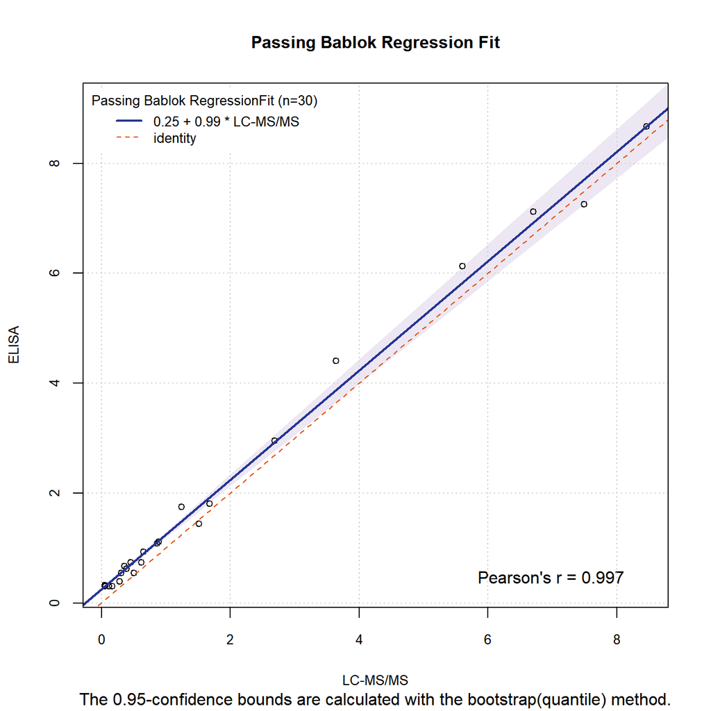